# Project 1

## Merge beer data with the breweries data and print the first 6 observations and the last six observations to check the merged file.

```r
Beer_Merge <- as.data.frame(merge(Beers, Breweries2, all = TRUE))
rhandsontable(head(Beer_Merge, n= 6))
```

[interactive table not shown]

```r
rhandsontable(tail(Beer_Merge, n= 6))
```

[interactive table not shown]

## Reported number of NA’s in each column

```r
rhandsontable(miss_var_summary(Beer_Merge))
```

[interactive table not shown]

We are also able to plot the missing variables per column.

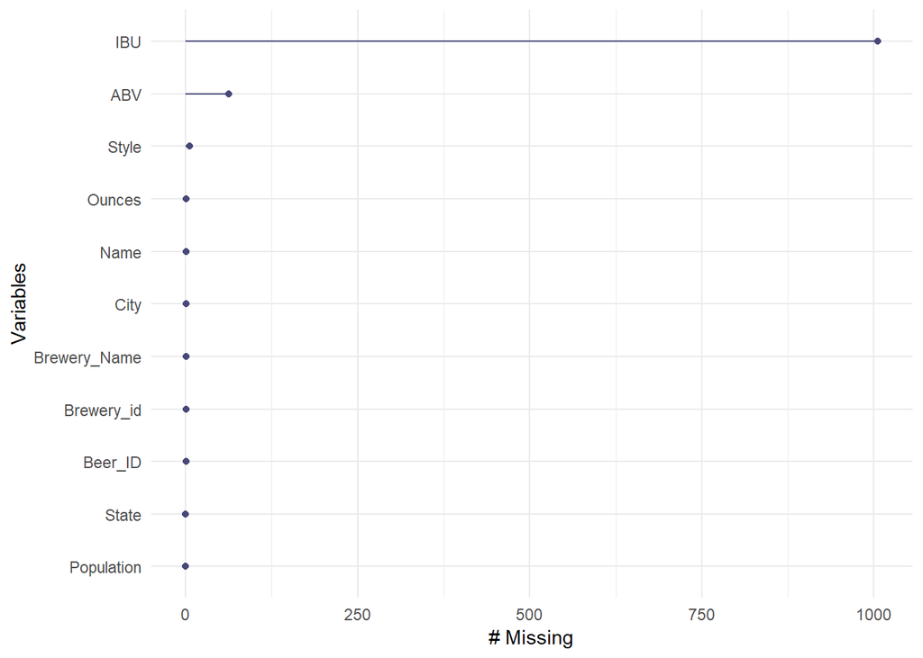

```r
gg_miss_var(Beer_Merge)
```

## Compute the median alcohol content and international bitterness unit for each state. Plot a bar chart to compare.

```r
ABV_IBU <- as.data.frame(aggregate(cbind(Beer_Merge$ABV, Beer_Merge$IBU) ~ Beer_Merge$State, Beer_Merge, median))

names(ABV_IBU) <- c("State", "ABV", "IBU")

rhandsontable(head(ABV_IBU))
```

[interactive table not shown]

Here we will use an interactive chart. Feel free to click and compare.

```r
highchart() %>%
  hc_yAxis_multiples(
    list(lineWidth = 3, lineColor='blue', title=list(text="ABV")),
    list(lineWidth = 3, lineColor="red", title=list(text="IBU"))
  ) %>%
  hc_add_series(data = ABV_IBU$ABV, color='blue', type = "column") %>%
  hc_add_series(data = ABV_IBU$IBU, color='red', type = "column", yAxis = 1) %>%
  hc_xAxis(categories = ABV_IBU$State, title = list(text = "State")) %>%
  hc_title(text = "<b>Median ABV and IBU by State</b>",
           margin = 20, align = "center",
           style = list(color="black", useHTML = TRUE))
```

[interactive chart not shown]

## Which state has the maximum alcoholic (ABV) beer?

```r
MaxABV <- Beer_Merge %>%
    slice( which.max(ABV)) %>%
    select(State, Name, ABV)

MaxIBU <- Beer_Merge %>%
    slice( which.max(IBU)) %>%
    select(State, Name, IBU)


rhandsontable(MaxABV, rowHeaders = NULL, trimWhitespace=TRUE)
```

[interactive table not shown]

## Which state has the most bitter (IBU) beer?

```r
rhandsontable(MaxIBU, rowHeaders = NULL, trimWhitespace=TRUE)
```

[interactive table not shown]

## Summary statistics for the ABV variable.

```r
sumStat <- as.data.frame(stat.desc(Beer_Merge$ABV))
names(sumStat) <- c("Summary")

rhandsontable(sumStat, rowHEaders=NULL, trimWhitespace=TRUE)
```

[interactive table not shown]

We can also provide a visual representation of ABV with a box plot.

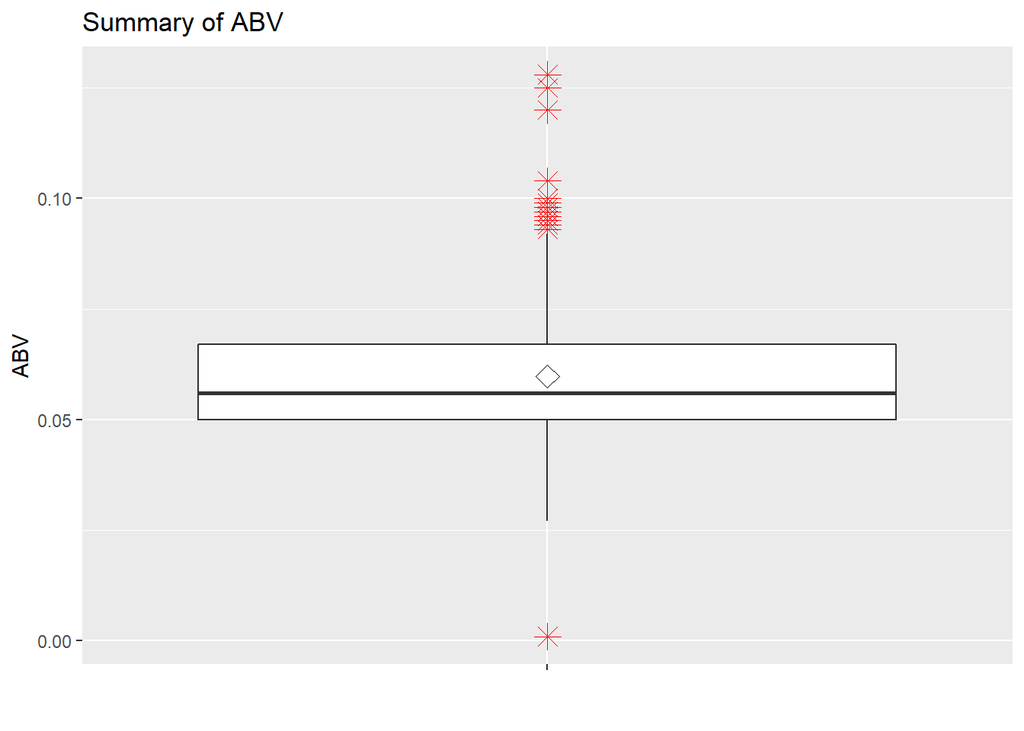

```r
ggplot(Beer_Merge, aes(x="", y=Beer_Merge$ABV)) +
  geom_boxplot(outlier.colour="red", outlier.shape=8,
                outlier.size=4) + stat_summary(fun.y=mean, geom="point", shape=23, size=4) + labs(y = "ABV", x = "", title = "Summary of ABV")
```

## Summary Statistics for the IBU variable

```r
sumStat <- as.data.frame(stat.desc(Beer_Merge$IBU))
names(sumStat) <- c("Summary")

rhandsontable(sumStat, rowHEaders=NULL, trimWhitespace=TRUE)
```

[interactive table not shown]

And the visual representation…

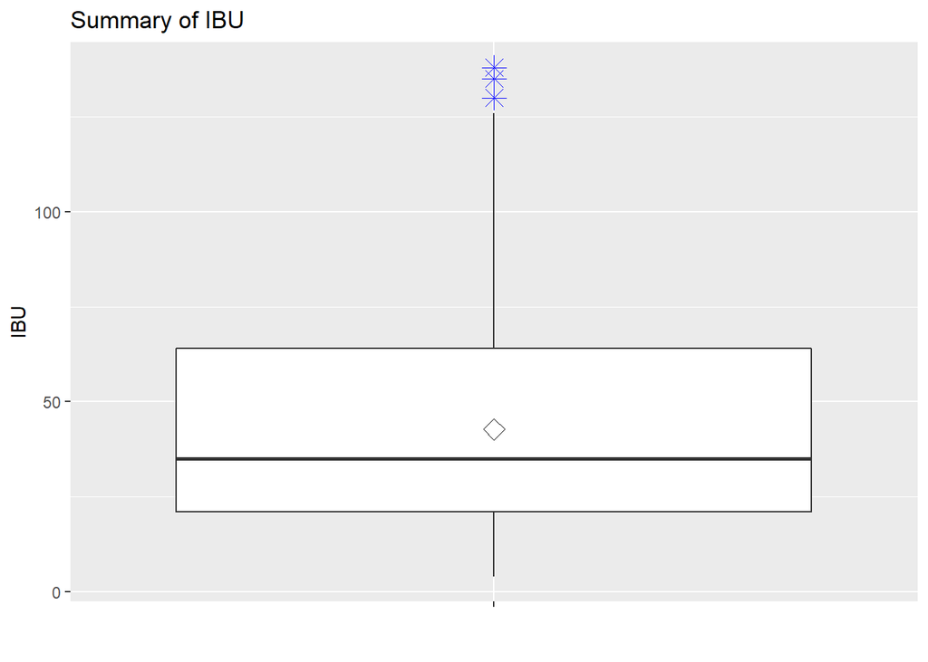

```r
ggplot(Beer_Merge, aes(x="", y=Beer_Merge$IBU)) +
  geom_boxplot(outlier.colour="Blue", outlier.shape=8,
                outlier.size=4) + stat_summary(fun.y=mean, geom="point", shape=23, size=4) + labs(y = "IBU", x = "", title = "Summary of IBU")
```

## Is there an apparent relationship between the bitterness of the beer and its alcoholic content?

It seems that from the scatterplot that there is a relationship.

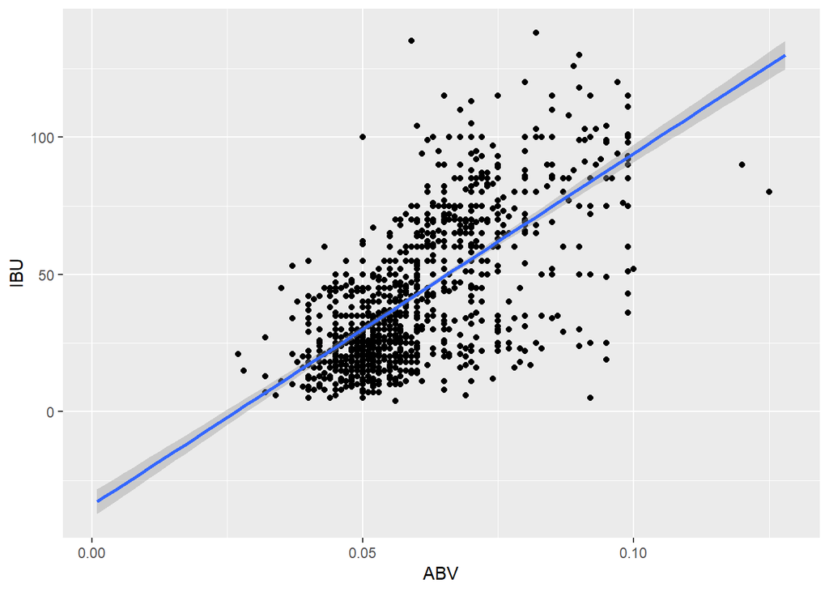

```r
Scatter_plot <- ggplot(Beer_Merge, aes(x = Beer_Merge$ABV, y= Beer_Merge$IBU)) + geom_point() + geom_smooth(method = "lm", se=TRUE, fullrange= TRUE, level= 0.95) + xlab("ABV") + ylab("IBU")

Scatter_plot
```

To confirm we can perform a one-way ANOVA. It appears that there is a significant relationship between the two.

```r
res.aov <- aov(Beer_Merge$ABV ~ Beer_Merge$IBU, data = Beer_Merge)

summary(res.aov)
```

```
##                  Df Sum Sq Mean Sq F value Pr(>F)
## Beer_Merge$IBU    1 0.1164  0.1164    1147 <2e-16 ***
## Residuals      1403 0.1424  0.0001
## ---
## Signif. codes:  0 '***' 0.001 '**' 0.01 '*' 0.05 '.' 0.1 ' ' 1
## 1006 observations deleted due to missingness
```